# Ford GoBike System Data Analysis and Exploration

## Introduction

> The Ford GoBike System dataset provides detailed information/data on the greater San Francisco Bay in regard to individual bike usage/ride in a bike sharing system.

> This document therefore explores the Ford GoBike System dataset to create meaningful visualizations (using both single and multi-variables), formulate insights, and draw cogent conclusions.

## Preliminary Wrangling

```python
# import all packages and set plots to be embedded inline
import numpy as np
import pandas as pd
import matplotlib.pyplot as plt
import seaborn as sb

%matplotlib inline
```

> Dataset is loaded, assessed and properties described appropriately to answer questions.

```python
ford_bike = pd.read_csv('fordgobike-tripdata.csv')
```

## Assessing

> Visually and programmatically exploring the dataset to detect quality/tidiness issues with the dataset that might negatively impact the data analysis process

```python
#overview of the dataset composition showing the first 5 rows.
ford_bike.head()
```

|  | duration_sec | start_time | end_time | start_station_id | start_station_name | start_station_latitude | start_station_longitude | end_station_id | end_station_name | end_station_latitude | end_station_longitude | bike_id | user_type | member_birth_year | member_gender | bike_share_for_all_trip |
| --- | --- | --- | --- | --- | --- | --- | --- | --- | --- | --- | --- | --- | --- | --- | --- | --- |
| 0 | 52185 | 2019-02-28 17:32:10.1450 | 2019-03-01 08:01:55.9750 | 21.0 | Montgomery St BART Station (Market St at 2nd St) | 37.789625 | -122.400811 | 13.0 | Commercial St at Montgomery St | 37.794231 | -122.402923 | 4902 | Customer | 1984.0 | Male | No |
| 1 | 42521 | 2019-02-28 18:53:21.7890 | 2019-03-01 06:42:03.0560 | 23.0 | The Embarcadero at Steuart St | 37.791464 | -122.391034 | 81.0 | Berry St at 4th St | 37.775880 | -122.393170 | 2535 | Customer | NaN | NaN | No |
| 2 | 61854 | 2019-02-28 12:13:13.2180 | 2019-03-01 05:24:08.1460 | 86.0 | Market St at Dolores St | 37.769305 | -122.426826 | 3.0 | Powell St BART Station (Market St at 4th St) | 37.786375 | -122.404904 | 5905 | Customer | 1972.0 | Male | No |
| 3 | 36490 | 2019-02-28 17:54:26.0100 | 2019-03-01 04:02:36.8420 | 375.0 | Grove St at Masonic Ave | 37.774836 | -122.446546 | 70.0 | Central Ave at Fell St | 37.773311 | -122.444293 | 6638 | Subscriber | 1989.0 | Other | No |
| 4 | 1585 | 2019-02-28 23:54:18.5490 | 2019-03-01 00:20:44.0740 | 7.0 | Frank H Ogawa Plaza | 37.804562 | -122.271738 | 222.0 | 10th Ave at E 15th St | 37.792714 | -122.248780 | 4898 | Subscriber | 1974.0 | Male | Yes |

```python
# Code to show the dataset shape

ford_bike.shape
```

```
(183412, 16)
```

```python
 # Code to provide a summary information about the dataset showing data types of the values and missing dataset

ford_bike.info()
```

```
<class 'pandas.core.frame.DataFrame'>
RangeIndex: 183412 entries, 0 to 183411
Data columns (total 16 columns):
duration_sec               183412 non-null int64
start_time                 183412 non-null object
end_time                   183412 non-null object
start_station_id           183215 non-null float64
start_station_name         183215 non-null object
start_station_latitude     183412 non-null float64
start_station_longitude    183412 non-null float64
end_station_id             183215 non-null float64
end_station_name           183215 non-null object
end_station_latitude       183412 non-null float64
end_station_longitude      183412 non-null float64
bike_id                    183412 non-null int64
user_type                  183412 non-null object
member_birth_year          175147 non-null float64
member_gender              175147 non-null object
bike_share_for_all_trip    183412 non-null object
dtypes: float64(7), int64(2), object(7)
memory usage: 22.4+ MB
```

```python
# Code to the sum of missing values in all the columns in the dataset.

ford_bike.isnull().sum()
```

```
duration_sec                  0
start_time                    0
end_time                      0
start_station_id            197
start_station_name          197
start_station_latitude        0
start_station_longitude       0
end_station_id              197
end_station_name            197
end_station_latitude          0
end_station_longitude         0
bike_id                       0
user_type                     0
member_birth_year          8265
member_gender              8265
bike_share_for_all_trip       0
dtype: int64
```

```python
# Code to check for duplicate data in the dataset

ford_bike.duplicated().sum()
```

```
0
```

```python
# Code to provide descriptive statistics

ford_bike.describe()
```

|  | duration_sec | start_station_id | start_station_latitude | start_station_longitude | end_station_id | end_station_latitude | end_station_longitude | bike_id | member_birth_year |
| --- | --- | --- | --- | --- | --- | --- | --- | --- | --- |
| count | 183412.000000 | 183215.000000 | 183412.000000 | 183412.000000 | 183215.000000 | 183412.000000 | 183412.000000 | 183412.000000 | 175147.000000 |
| mean | 726.078435 | 138.590427 | 37.771223 | -122.352664 | 136.249123 | 37.771427 | -122.352250 | 4472.906375 | 1984.806437 |
| std | 1794.389780 | 111.778864 | 0.099581 | 0.117097 | 111.515131 | 0.099490 | 0.116673 | 1664.383394 | 10.116689 |
| min | 61.000000 | 3.000000 | 37.317298 | -122.453704 | 3.000000 | 37.317298 | -122.453704 | 11.000000 | 1878.000000 |
| 25% | 325.000000 | 47.000000 | 37.770083 | -122.412408 | 44.000000 | 37.770407 | -122.411726 | 3777.000000 | 1980.000000 |
| 50% | 514.000000 | 104.000000 | 37.780760 | -122.398285 | 100.000000 | 37.781010 | -122.398279 | 4958.000000 | 1987.000000 |
| 75% | 796.000000 | 239.000000 | 37.797280 | -122.286533 | 235.000000 | 37.797320 | -122.288045 | 5502.000000 | 1992.000000 |
| max | 85444.000000 | 398.000000 | 37.880222 | -121.874119 | 398.000000 | 37.880222 | -121.874119 | 6645.000000 | 2001.000000 |

## Data Cleaning

> Revamping dataset to improve its quality and viability for effective analysis and visualization. Cleaning included:
> 1. Dropping redundant columns
> 2. Converting date/time fields to Datetime time stamp
> 3. Filling missing data in member_gender and member_birth_year columns

```python
# Eliminating dataset that would be useful in my analysis and discussions

ford_bike.drop(['start_station_id','start_station_latitude','start_station_longitude','end_station_id','end_station_latitude','end_station_longitude'], axis = 1, inplace = True)

# Confirming
ford_bike.info()
```

```
<class 'pandas.core.frame.DataFrame'>
RangeIndex: 183412 entries, 0 to 183411
Data columns (total 10 columns):
duration_sec               183412 non-null int64
start_time                 183412 non-null object
end_time                   183412 non-null object
start_station_name         183215 non-null object
end_station_name           183215 non-null object
bike_id                    183412 non-null int64
user_type                  183412 non-null object
member_birth_year          175147 non-null float64
member_gender              175147 non-null object
bike_share_for_all_trip    183412 non-null object
dtypes: float64(1), int64(2), object(7)
memory usage: 14.0+ MB
```

```python
# Convert date / time variables to datetime data type

ford_bike['start_time'] = pd.to_datetime(ford_bike['start_time'])

ford_bike['end_time'] = pd.to_datetime(ford_bike['end_time'])

# Confirming

ford_bike.dtypes
```

```
duration_sec                        int64
start_time                 datetime64[ns]
end_time                   datetime64[ns]
start_station_name                 object
end_station_name                   object
bike_id                             int64
user_type                          object
member_birth_year                 float64
member_gender                      object
bike_share_for_all_trip            object
dtype: object
```

```python
# Code to find the mean ages of all the bikers

average_age = 2022 - ford_bike.member_birth_year.mean()
average_age
```

```
37.193563121263878
```

```python
#Filling Missing values in member_birth_year column with average age

ford_bike["member_birth_year"] = ford_bike["member_birth_year"].fillna(round(ford_bike["member_birth_year"].mean())).astype('int32')

#Confirming
ford_bike.info()
```

```
<class 'pandas.core.frame.DataFrame'>
RangeIndex: 183412 entries, 0 to 183411
Data columns (total 10 columns):
duration_sec               183412 non-null int64
start_time                 183412 non-null datetime64[ns]
end_time                   183412 non-null datetime64[ns]
start_station_name         183215 non-null object
end_station_name           183215 non-null object
bike_id                    183412 non-null int64
user_type                  183412 non-null object
member_birth_year          183412 non-null int32
member_gender              175147 non-null object
bike_share_for_all_trip    183412 non-null object
dtypes: datetime64[ns](2), int32(1), int64(2), object(5)
memory usage: 13.3+ MB
```

```python
# Coverting duration from seconds to minutes and creating a new column duration_min
duration_min = []
seconds = ford_bike['duration_sec']
for sec in seconds:
    ## Minutes values are rounded to whole numbers
    minute = sec // 60
    duration_min.append(minute)

ford_bike['duration_min'] = duration_min
# Confirming
ford_bike.head()
```

|  | duration_sec | start_time | end_time | start_station_name | end_station_name | bike_id | user_type | member_birth_year | member_gender | bike_share_for_all_trip | duration_min |
| --- | --- | --- | --- | --- | --- | --- | --- | --- | --- | --- | --- |
| 0 | 52185 | 2019-02-28 17:32:10.145 | 2019-03-01 08:01:55.975 | Montgomery St BART Station (Market St at 2nd St) | Commercial St at Montgomery St | 4902 | Customer | 1984 | Male | No | 869 |
| 1 | 42521 | 2019-02-28 18:53:21.789 | 2019-03-01 06:42:03.056 | The Embarcadero at Steuart St | Berry St at 4th St | 2535 | Customer | 1985 | NaN | No | 708 |
| 2 | 61854 | 2019-02-28 12:13:13.218 | 2019-03-01 05:24:08.146 | Market St at Dolores St | Powell St BART Station (Market St at 4th St) | 5905 | Customer | 1972 | Male | No | 1030 |
| 3 | 36490 | 2019-02-28 17:54:26.010 | 2019-03-01 04:02:36.842 | Grove St at Masonic Ave | Central Ave at Fell St | 6638 | Subscriber | 1989 | Other | No | 608 |
| 4 | 1585 | 2019-02-28 23:54:18.549 | 2019-03-01 00:20:44.074 | Frank H Ogawa Plaza | 10th Ave at E 15th St | 4898 | Subscriber | 1974 | Male | Yes | 26 |

```python
## Creating an age column

age_bikers = []
ages =  2022- ford_bike.member_birth_year
for age in ages:
    age_bikers.append(age)

ford_bike['age_bikers'] = age_bikers
# Confirming
ford_bike.head()
```

|  | duration_sec | start_time | end_time | start_station_name | end_station_name | bike_id | user_type | member_birth_year | member_gender | bike_share_for_all_trip | duration_min | age_bikers |
| --- | --- | --- | --- | --- | --- | --- | --- | --- | --- | --- | --- | --- |
| 0 | 52185 | 2019-02-28 17:32:10.145 | 2019-03-01 08:01:55.975 | Montgomery St BART Station (Market St at 2nd St) | Commercial St at Montgomery St | 4902 | Customer | 1984 | Male | No | 869 | 38 |
| 1 | 42521 | 2019-02-28 18:53:21.789 | 2019-03-01 06:42:03.056 | The Embarcadero at Steuart St | Berry St at 4th St | 2535 | Customer | 1985 | NaN | No | 708 | 37 |
| 2 | 61854 | 2019-02-28 12:13:13.218 | 2019-03-01 05:24:08.146 | Market St at Dolores St | Powell St BART Station (Market St at 4th St) | 5905 | Customer | 1972 | Male | No | 1030 | 50 |
| 3 | 36490 | 2019-02-28 17:54:26.010 | 2019-03-01 04:02:36.842 | Grove St at Masonic Ave | Central Ave at Fell St | 6638 | Subscriber | 1989 | Other | No | 608 | 33 |
| 4 | 1585 | 2019-02-28 23:54:18.549 | 2019-03-01 00:20:44.074 | Frank H Ogawa Plaza | 10th Ave at E 15th St | 4898 | Subscriber | 1974 | Male | Yes | 26 | 48 |

```python
# Filling missing gender entries randomly

ford_bike["member_gender"] = ford_bike["member_gender"].fillna(np.random.choice(["Male","Female"]))

ford_bike.info()
```

```
<class 'pandas.core.frame.DataFrame'>
RangeIndex: 183412 entries, 0 to 183411
Data columns (total 12 columns):
duration_sec               183412 non-null int64
start_time                 183412 non-null datetime64[ns]
end_time                   183412 non-null datetime64[ns]
start_station_name         183215 non-null object
end_station_name           183215 non-null object
bike_id                    183412 non-null int64
user_type                  183412 non-null object
member_birth_year          183412 non-null int32
member_gender              183412 non-null object
bike_share_for_all_trip    183412 non-null object
duration_min               183412 non-null int64
age_bikers                 183412 non-null int64
dtypes: datetime64[ns](2), int32(1), int64(4), object(5)
memory usage: 16.1+ MB
```

```python
## Lastly dropping all columns with non available data
ford_bike.dropna()

#Confirmation
ford_bike.info()
```

```
<class 'pandas.core.frame.DataFrame'>
RangeIndex: 183412 entries, 0 to 183411
Data columns (total 12 columns):
duration_sec               183412 non-null int64
start_time                 183412 non-null datetime64[ns]
end_time                   183412 non-null datetime64[ns]
start_station_name         183215 non-null object
end_station_name           183215 non-null object
bike_id                    183412 non-null int64
user_type                  183412 non-null object
member_birth_year          183412 non-null int32
member_gender              183412 non-null object
bike_share_for_all_trip    183412 non-null object
duration_min               183412 non-null int64
age_bikers                 183412 non-null int64
dtypes: datetime64[ns](2), int32(1), int64(4), object(5)
memory usage: 16.1+ MB
```

### What is/are the main feature(s) of interest in your dataset?

> I am most interested in finding the correlation between member_gender, age_bikers, user_type, bike shares members and duration of trips.

> I am also interested in how the several variables such as member_gender, age_bikers, user_type, bike shares members correlate specifically/individually with the trip duration.

### What features in the dataset do you think will help support your investigation into your feature(s) of interest?

> 1. Member gender
> 2. Ages of the bikers
> 3. User types (Customer/Subscriber)
> 4. Duration of the trips
> 5. Bike Share Program member

## Univariate Exploration

> In this section, I investigated distributions of individual variables. I employed barcharts, histograms and barplots for exploration.

### Question : What type of gender recorded high trip counts or mostly patronizes the bike services?

### Visualization

```python
## Creating plot function for subsequent plots
y = 'x'
def plot(y):
    ford_bike[y].value_counts().index
    plt.figure(figsize = (8,5))
    #color = sb.color_palette()[1]
    sb.countplot(data= ford_bike , x = y, order = ford_bike[y].value_counts().index)
    plt.grid()
```

```
Text(0.5,1,'Number of trips by Genders')
```

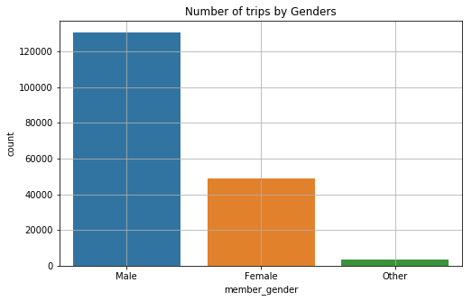

```python
## Code to plot the trip count levels of the among the types of genders

plot('member_gender')
plt.title('Number of trips by Genders')
```

### Observation

The above visualization clearly shows that most of the users/cyclists patronizing the bike services are males.

### Question : What user type recorded high trip counts or mostly patronized the bike services?

### Visualization

```
Text(0.5,1,'Number of trip by user types')
```

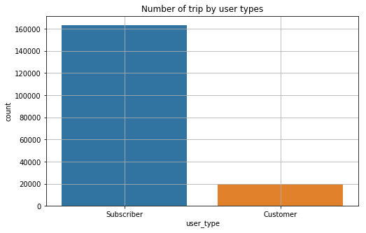

```python
## Calling the function plot

plot('user_type')
plt.title('Number of trip by user types')
```

### Qbservation

From the above visualization, it could be observed that cyclists patronizing the bike services for trips are mostly subscribed service users

### Question : What is the impact of the bike sharing membership program on the frequency/counts of trips or on the patronage of the bikes?

### Visualization

```
Text(0.5,1,'Number of trips by bike share membership program')
```

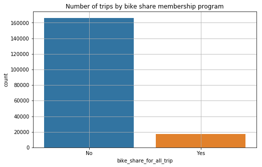

```python
## Calling plot function

plot('bike_share_for_all_trip')
plt.title('Number of trips by bike share membership program')
```

### Observation

It can be observed from the above visualization that most trips are made by cyclists not enrolled in the Bike Share for All membership program. The membership program therefore has a lower impact on the counts of trips made by a cyclist and users not registering for the program won't affect the patronage of the bike service.

### Question : What impact does that age of the cyclists/bikers have on the number of trips or rate of patronage of the bike service.

```python
## The minimum and maximum of ages of the cyclists are observed before visualization
## to take notes of outliers and invalid data in ages
```

```python
# Code showing an old age of 144 years which makes the data invalid

ford_bike['age_bikers'].max()
```

```
144
```

```python
# Code showing a minimum age of 21 years which is a valid age for visualization and analysis

ford_bike['age_bikers'].min()
```

```
21
```

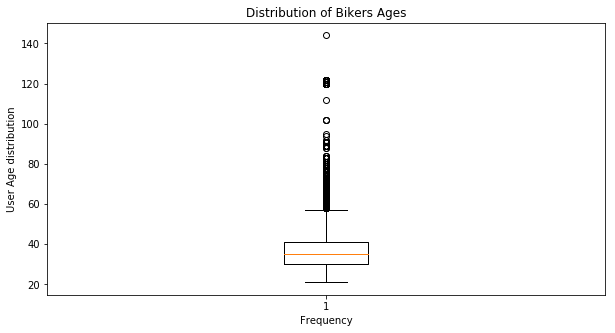

```python
# Code to show Age outliers

plt.figure(figsize = (10,5))

#ford_bike['age_bikers'].boxplot(vert = False)- Alternate code to plot
plt.boxplot(ford_bike['age_bikers'])
plt.ylabel('User Age distribution')
plt.xlabel('Frequency')
plt.title("Distribution of Bikers Ages")

plt.show()
```

The above chart clearly depicts an outlier age of above 140 years old.

```python
## Code to apply only valid ages from the ages of 21 to 50  for analysis and visualization. For instance a rider with a maximum
## age of 144 years won't be capable of patronizing the biker service hence that data is an outlier in our dataset

ford_bike['age_bikers'] = ford_bike['age_bikers'].apply(lambda x:x if x > 0 else ford_bike['age_bikers'].mean())

# Code to drop invalid ages
ford_bike.drop(ford_bike[ford_bike['age_bikers'] > 50].index, inplace = True)

# Confirm
ford_bike['age_bikers'].max()
```

```
50
```

```
Text(0.5,1,'Number of trips by ages')
```

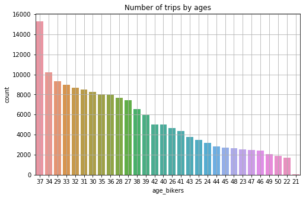

```python
## Calling Plot function

plot('age_bikers')
plt.title('Number of trips by ages')
```

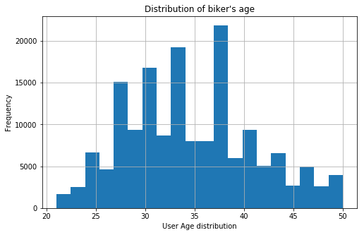

```python
# Code to distribute the user's age

plt.figure(figsize = (8,5))

#ford_bike['age_bikers'].hist(bins= 20); - Alternative code to plot
plt.hist(data = ford_bike, x ='age_bikers', bins = 20)
plt.xlabel('User Age distribution')
plt.ylabel('Frequency')
plt.title("Distribution of biker's age")
plt.grid()

plt.show()
```

### Observation

From the above visualization it can be observed that cyclists/bikers who are 37 years, recorded the most number of trips and the bikers with the minimum age of 21 years almost did not make any trip at all.

### Question: What time duration has the highest trip counts ?

### Visualization

```python
ford_bike['duration_min'].max()
```

```
1424
```

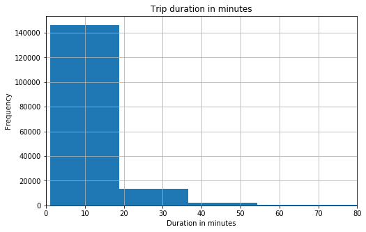

```python
plt.figure(figsize = (8,5))
ford_bike['duration_min'].hist(bins=80)
plt.xlabel('Duration in minutes')
plt.ylabel('Frequency')
plt.xlim(0, 80)
plt.title("Trip duration in minutes")

plt.show()
```

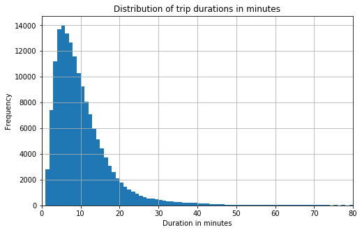

```python
plt.figure(figsize = (8,5))
# Code to change the bin number/limit
bins = np.arange(0, ford_bike.duration_min.max()+1, 1)
plt.hist(data = ford_bike, x = 'duration_min', bins = bins)
plt.xlabel('Duration in minutes')
plt.ylabel('Frequency')
plt.xlim(0, 80)
plt.title("Distribution of trip durations in minutes")
plt.grid()
plt.show()
```

### Observation

> 1.It can observed from the 1st visualization that most of the user trips have a trip duration between 0 mins and 20 mins signalling a higher usage for short-duration trips.

> 2.It can be observed from the distribution of the second plot how the frequency of the usage inceases between 0 and about 5 mins trip duration and gradually reduces with increasing duration in trip minutes.

### Distribution(s) of variable(s) of interest and outliers

> 1. Most of the cyclisyts using the bike service are Males, Subscribers and are not enrolled into the Bike Trip for All membership program as visualized in the charts above.
> 2. It can be noticed that most of the trips were less than 20 minutes (less than half an hour) as shown by the distribution of duration in minutes.
> 3. Most of the bike users are between the ages of 26 and 43 years with highest recorded trip counts at 37 years old.The distribution also shows a left skew.
> 4. There were age outliers for more than 80 years old shown by the boxplot age distribution.

### Features of interest and data tidy

> 1. Because of the age outliers and the invalidity of the data in the age coloumns, I filtered out ages greater than 50 years for my analysis/visualization.
> 2. The distribution of the trip duration in minutes was also quite interesting since shorter trip duration recorded higher frequency. This could signal a higher bike usage for short-duration trips but not long-duration trips.
> 3. The age interval of the bike users was also quite interesting creating an insight that middle-aged users mostly purchace the bike services.

## Bivariate Exploration

> In this section, I investigated the relationships between pairs of variables in dataset capturing features of interests discussed under the univeariate exploration.

### Question: What is the trip duration for each gender in the dataset/ Which gender recorded higher trip durations?

### Code

```python
# Initiallizing a function plot1 to plot subsequent barplots.
p = 'p'
z = 'z'
def plot1(p,z):
    plt.figure(figsize = (8,5))
    sb.barplot(data = ford_bike, x = p, y = z)
```

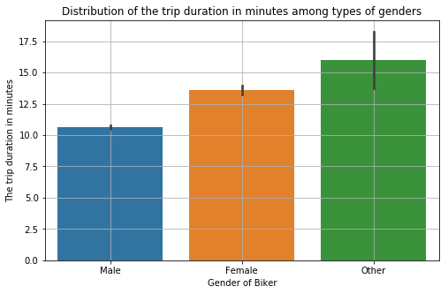

```python
# Calling Plot1 to plot grpah of trip duration against member gender

plot1('member_gender', 'duration_min')
plt.xlabel('Gender of Biker')
plt.ylabel('The trip duration in minutes')
plt.title('Distribution of the trip duration in minutes among types of genders')
plt.grid()
plt.show()
```

### Observation

From the above visualization, it can be observed that the male users recorded the lowest trip duration among all genders with other gender types recording the highest.

### Question: Which user type recorded the highest trip duration/what is the trip duration for each user type?

### Code

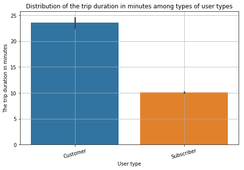

```python
## Calling function plot to plot correlation between user types and trip duration

plot1('user_type','duration_min')
plt.xlabel('User type')
plt.ylabel('The trip duration in minutes')
plt.xticks(rotation = 15)
plt.title('Distribution of the trip duration in minutes among types of user types')
plt.grid()
plt.show()
```

### Observation

It can observed that the customer user type of the bike service had longer trip duration than the subscriber user type

### Question What is the correlation between the trip duration and age of the bikers

### Code

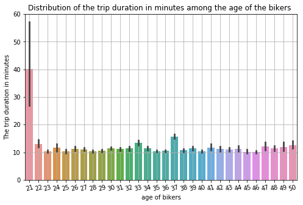

```python
plot1('age_bikers','duration_min')
plt.xlabel('age of bikers')
plt.ylabel('The trip duration in minutes')
plt.xticks(rotation = 15)
plt.title('Distribution of the trip duration in minutes among the age of the bikers ')
plt.grid()
plt.show()
```

### Observation

It can be observed that the bikers of 21 years of age take longer trips.

### Question: What is the correlation between the user types and the types of gender in the dataset.

### Code

```python
ford_bike.groupby('user_type')['member_gender'].value_counts()
```

```
user_type   member_gender
Customer    Male              10337
            Female             7493
            Other               420
Subscriber  Male             104675
            Female            38041
            Other              2662
Name: member_gender, dtype: int64
```

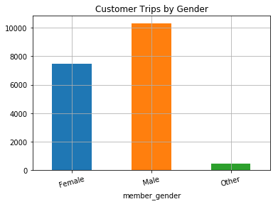

```python
# Code to plot distribution of customer users among gender types
ford_bike.groupby(['member_gender', 'user_type']).size().unstack()['Customer'].plot(kind='bar', title = 'Customer Trips by Gender')
plt.xticks(rotation = 15)
plt.grid()
plt.show()
```

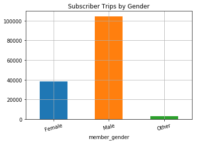

```python
# Code to plot distribution of subscriber users among gender types
ford_bike.groupby(['member_gender', 'user_type']).size().unstack()['Subscriber'].plot(kind='bar', title = 'Subscriber Trips by Gender')
plt.xticks(rotation = 15)
plt.grid()
plt.show()
```

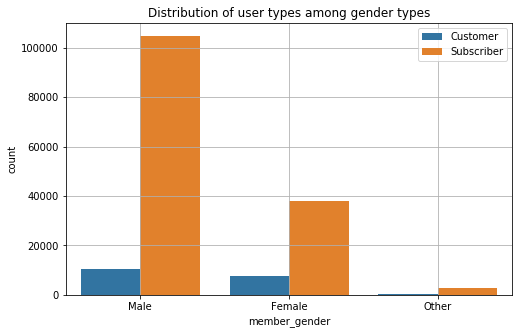

```python
# Plot showing distribution of both user types among gender types

plt.figure(figsize = [8, 5])
sb.countplot(data = ford_bike, x = 'member_gender', hue = 'user_type')
plt.legend()
plt.title('Distribution of user types among gender types')
plt.grid()
```

### Observation

It can be observed from the three visualization above that a majority of subscriber and customer trips are taken by males.

### Question: What is the correlation between the members of the bike share program and user types

### Code

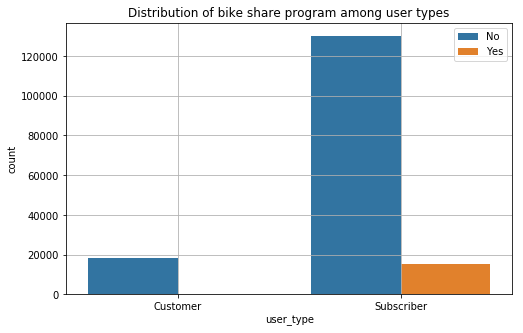

```python
plt.figure(figsize = [8, 5])
sb.countplot(data = ford_bike, x = 'user_type', hue = 'bike_share_for_all_trip')
plt.legend()
plt.title('Distribution of bike share program among user types')
plt.grid()
```

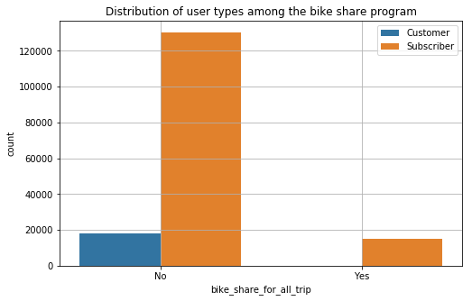

```python
plt.figure(figsize = [8, 5])
sb.countplot(data = ford_bike, x = 'bike_share_for_all_trip', hue = 'user_type')
plt.legend()
plt.title('Distribution of user types among the bike share program')
plt.grid()
```

### Observation

> 1. From the two plots depicted above, it can observed that majority of the subscriber users did not enroll in the Bike share program.

### Talk about some of the relationships you observed in this part of the investigation. How did the feature(s) of interest vary with other features in the dataset?

> 1. Other gender types go for longer trips than both male and female genders.
> 2. Customer users take longer trips than subsciber users.
> 3. Male gender makes up most of both subscriber and customer user types.
> 4. Majority of the subscriber user did not enroll in the bike share membership program . Also no customer enrolled in the bike share program.

## Multivariate Exploration

> In this section we explore relationships between different sets of three or more variables

### Question: What is the mean trip duration distribution across the various gender types for the user types and members in the bike share program?

### Code

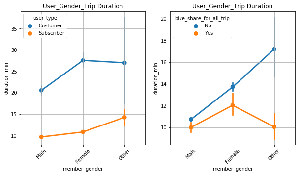

```python
# Code to plot trip duration distribution among gender types for the types of users
plt.figure(figsize=(10,5))
plt.subplot(1,2,1)
sb.pointplot(data= ford_bike, x='member_gender', y='duration_min', hue='user_type')
plt.title("User_Gender_Trip Duration");
plt.xticks(rotation=45)
plt.grid()


# Code to plot trip duration distribution among gender types for the bike share program members
plt.subplot(1,2,2)
sb.pointplot(data= ford_bike, x='member_gender', y='duration_min', hue='bike_share_for_all_trip')
plt.title("User_Gender_Trip Duration");
plt.xticks(rotation=45)
plt.grid()
```

### Question: What is the mean trip duration distribution across the user ages for the gender types, user types and members in the bike share program?

### Code

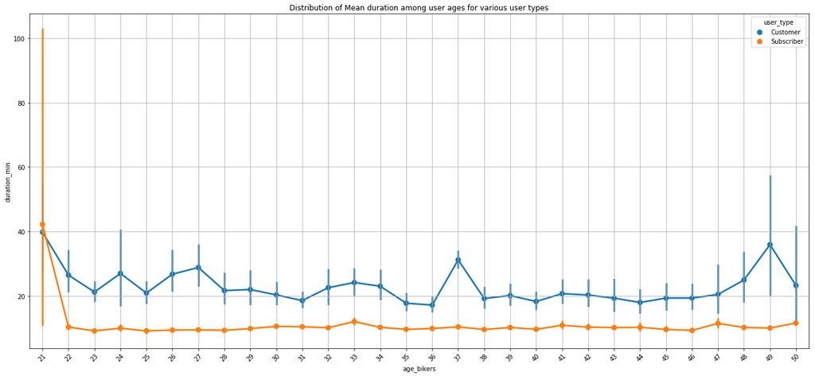

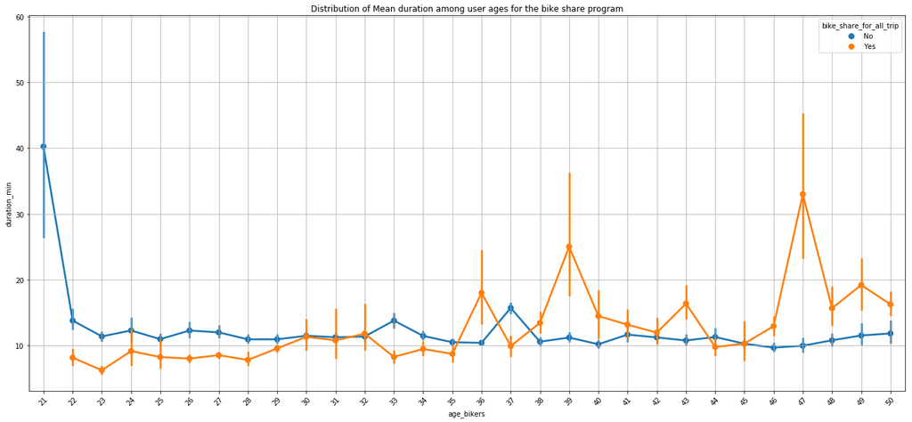

```python
# Plot mean trip duration distribution across user ages for the various user types
plt.figure(figsize=(50,10))
plt.subplot(1,2,1)
sb.pointplot(data= ford_bike, x='age_bikers', y='duration_min', hue='user_type')
plt.title("Distribution of Mean duration among user ages for various user types");
plt.xticks(rotation=45)
plt.grid()

# Plot mean trip duration distribution across user ages for the bike share pragram
plt.figure(figsize=(50,10))
plt.subplot(1,2,2)
sb.pointplot(data= ford_bike, x='age_bikers', y='duration_min', hue='bike_share_for_all_trip')
plt.title("Distribution of Mean duration among user ages for the bike share program");
plt.xticks(rotation=45)
plt.grid()
```

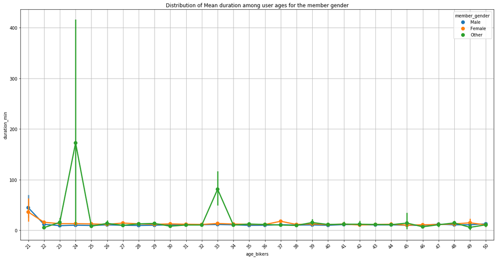

```python
plt.figure(figsize=(20,10))
sb.pointplot(data= ford_bike, x='age_bikers', y='duration_min', hue='member_gender')
plt.title("Distribution of Mean duration among user ages for the member gender");
plt.xticks(rotation=45)
plt.grid()
```

### Observation

> 1. It was observed that customers and subscribers who are 21 years of age averagely make longer trips than the user types of the other ages.
> 2. It can again be observed that users not enrolled in the Bike program who are 21 years old averagely make longer trips and users enrolled in the program who are 47 years old also averagely make longer trips than the other age groups.
> 3. Lastly, it was observed that there was a sharp increase in the the mean trip duration for other gender types from age 23 to 24 and sharp decline from age 24 to 25

### Question: What is the general correlation between each variable in the dataset?

### Code

```
<function matplotlib.pyplot.show(*args, **kw)>
```

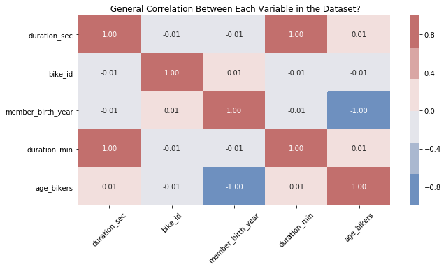

```python
## Code to plot a heatmap showing the correlation between varaibles.

plt.figure(figsize = (10,5))

color = sb.color_palette("vlag")

sb.heatmap(ford_bike.corr(), annot = True, fmt = '.2f', cmap = color)
plt.title(" General Correlation Between Each Variable in the Dataset?")

plt.xticks(rotation = 45)

plt.legend(loc='upper left')
plt.show
```

### Talk about some of the relationships you observed in this part of the investigation. Were there features that strengthened each other in terms of looking at your feature(s) of interest?

> 1. Customers and users not enrolled in the bike share program continue to take longer trips across all the genders.
> 2. Customers continue to take longer trips across all ages.
> 3. The trip duration is virtually the same for those not enrolled in the bike share program across the user ages, while it increases and decreases considerably for users enrolled in the program across mid thirties ages to the 50 years old.
> 4. The trip duration trends practically the same for users of all gender types across all ages except for other gender type of ages 24 and 33.
> 5. There is a weak negative and positive correlation between varaibles.

### Were there any interesting or surprising interactions between features?

> Users enrolled in the bike share program who were 47 years old were making longer trips than most young people.

> Females who enrolled and did not enrolled were both averagely making the same trip duration.

> Subscriber users were virtually making the same trip duration across all ages.

## Reference

1. https://matplotlib.org/stable/index.html
2. https://pandas.pydata.org/docs/getting_started/index.html
3. https://seaborn.pydata.org/tutorial/color_palettes.html
4. https://www.kaggle.com/code/nancyalaswad90/data-visualization-trip-data-ford-go-bike
5. https://www.kaggle.com/code/walidsi/fordgobike-exploration-ipynb